# Machine Learning Coursera Project

Olivier Cazin

26 juin 2016

## Introduction

Using devices such as Jawbone Up, Nike FuelBand, and Fitbit it is now possible to collect a large amount of data about personal activity relatively inexpensively. These type of devices are part of the quantified self movement – a group of enthusiasts who take measurements about themselves regularly to improve their health, to find patterns in their behavior, or because they are tech geeks. One thing that people regularly do is quantify how much of a particular activity they do, but they rarely quantify how well they do it.

In this project, our goal will be to use data from accelerometers on the belt, forearm, arm, and dumbell of 6 participants.

They were asked to perform barbell lifts correctly and incorrectly in 5 different ways : - Class A: exactly according to the specification - Class B: throwing the elbows to the front - Class C: lifting the dumbbell only halfway - Class D: lowering the dumbbell only halfway - Class E: throwing the hips to the front More information is available from the website here: (http://groupware.les.inf.puc-rio.br/har)

The data for this project come from this source: [Velloso, E.; Bulling, A.; Gellersen, H.; Ugulino, W.; Fuks, H. Qualitative Activity Recognition of Weight Lifting Exercises. Proceedings of 4th International Conference in Cooperation with SIGCHI (Augmented Human ’13) . Stuttgart, Germany: ACM SIGCHI, 2013] (http://groupware.les.inf.puc-rio.br/work.jsf?p1=11201)

The goal of our project is to predict the manner in which they did the exercise. This is the “classe” variable in the training set.

## 1. Loading R packages

At first, useful R packages are loaded.

```r
require(caret)
require(dplyr)
require(FactoMineR)
require(factoextra)
require(ggplot2)
require(randomForest)
require(rpart)
require(rpart.plot)
```

## 2. Importing files

Then, training-test and validation files are imported and we display their structure. We consider the 20 test cases as a validation dataset and we’ll split the other dataset as one training dataset and one test dataset)

```r
trainUrl <- "https://d396qusza40orc.cloudfront.net/predmachlearn/pml-training.csv"
testUrl <- "https://d396qusza40orc.cloudfront.net/predmachlearn/pml-testing.csv"
data.train <- read.csv(url(trainUrl), na.strings=c("NA","","#DIV/0!"))
data.validation <- read.csv(url(testUrl), na.strings=c("NA","","#DIV/0!"))
str(data.train,list.len=ncol(data.train))
str(data.validation,list.len=ncol(data.validation))
```

[output not shown]

## 3. Inspecting, cleaning et preparing data

The 7th variables are removed because they are not relevant to accelerometer measurements. Only arm, belt, dumbbell, and forearm features without missing values in test files could be predictors.

```r
# Inspecting train et validation dataset
summary(data.train)
summary(data.validation)
# Removing the 7th columns which are not relevant to accelerometer measurements
data.train.cleaned <- data.train[,-seq(1:7)]
data.validation.cleaned <- data.validation[,-seq(1:7)]
# Removing columns with NA missing values
na.test <-  function (x) {
  w <- sapply(x, function(x)all(is.na(x)))
  }
na.test.results <- na.test(data.validation.cleaned)
data.validation.cleaned <- data.validation.cleaned[,!na.test.results]
data.train.cleaned <- data.train.cleaned[,!na.test.results]
```

## 4. Creating training and test dataset

```r
set.seed(1567)
inTrain <- createDataPartition(data.train.cleaned$classe, p=0.60, list=F)
train <- data.train.cleaned[inTrain, ]
test <- data.train.cleaned[-inTrain, ]
```

## 5. Short Data Exploratory Analysis

All variables are quantitative, so in a 1st approach we could opt for a Principal Component Analysis (PCA) which could be particulary useful for data reduction and if there’s a relative linear correlations between factors.

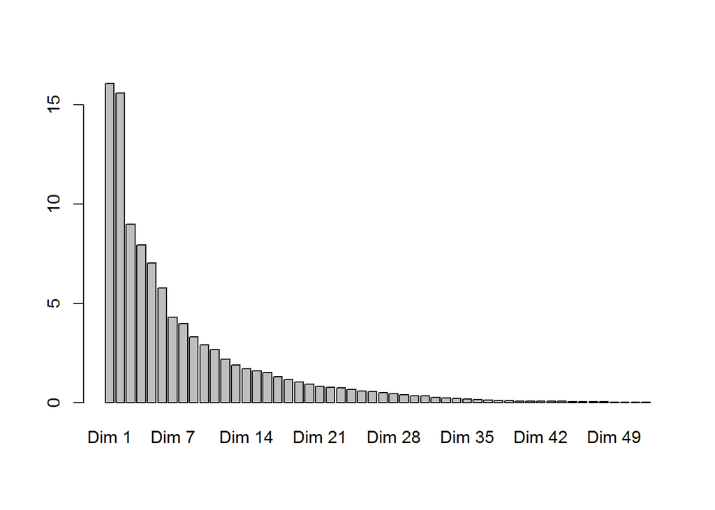

```r
# Principal Component Analysis
res <- PCA(data.train.cleaned[,c(1:52)],scale.unit=TRUE,graph=FALSE)
res <- PCA(data.train.cleaned,quali.sup=53,graph=FALSE)
# Decrease of eigenvalues
barplot(res$eig[,2],names=paste("Dim",1:nrow(res$eig)))
```

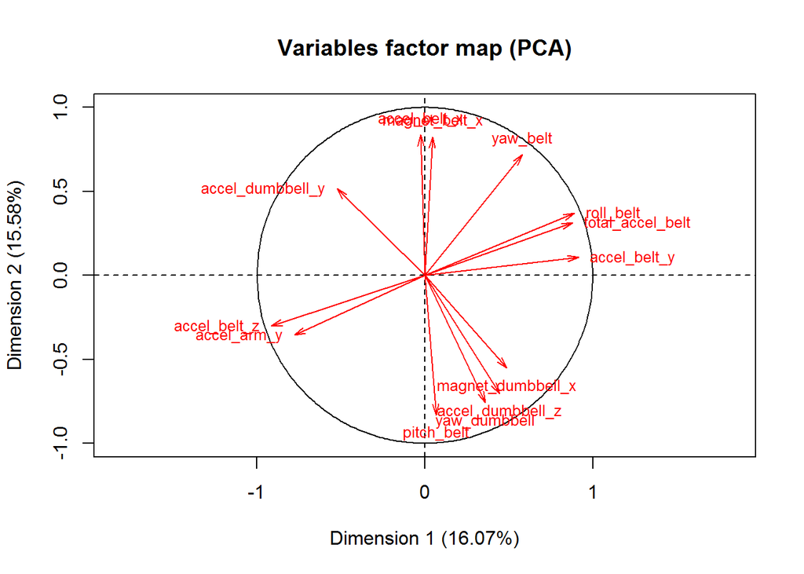

```r
# Display only variables with good representation
graph.var (res, draw=c("var","Points"), label=c("var","Points"), lim.cos2.var=0.5, new.plot=TRUE,cex=0.8,col.sup="blue",col.var="red")
```

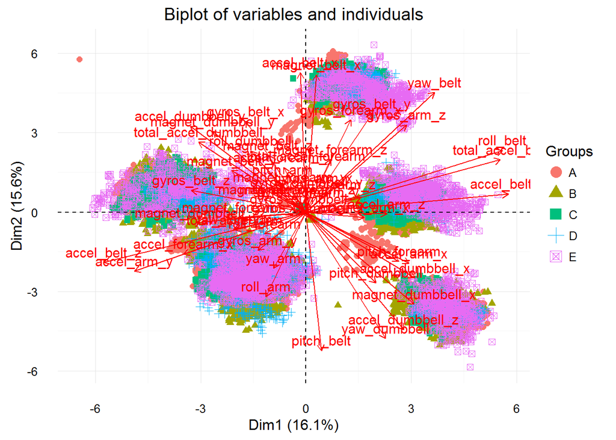

```r
# Chart individuals / variables from the results of the Principal Component Analysis (PCA).
fviz_pca_biplot(res,label="var",col.ind="cos2",col.var="red",habillage=data.train.cleaned$classe) + theme_minimal()
```

According to the decrease of the eigenvalues, we could retain the 6th axes. We can see in the 1st factorial plan (axes 1 and 2), the best represented variables (for exemple accel_belt_y and accel_belt_z which seems to be negatively correlated…). But in the Chart individuals/variables if we can identify 5 groups of individuals, these groups don’t correspond to the 5 ways to do exercices (Class A to Class E) ! So we suspect non linear correlations between factors. MCA could capture non linear correlations but we’ll have to discretize all variables. Our objective is only to define a predictive model and not an explanatory model, so i opt directly to test Random Forests, Boosting methods and compare them to Linear Discriminant Analysis which serves as a reference.

## 6. Preprocessing and Predictions with LDA, Random Forest and Boosting

We normalize the variables and run LDA, Random Forests and Boosting algorithms and compare their confusion matrix to select the best model. We could do more by tranforming variables but our results seems fisrtly to be efficient enough.

```r
# Predicting with LDA (Linear Discriminant Analysis) --> ~70% Accuracy
modelFitLDA <- train(train$classe ~.,method="lda",data=train,preProcess=c("center","scale"))
confusionMatrix(test$classe,predict(modelFitLDA,test))
```

```
## Confusion Matrix and Statistics
##
##           Reference
## Prediction    A    B    C    D    E
##          A 1817   45  187  176    7
##          B  236  989  173   49   71
##          C  127  155  888  165   33
##          D   74   54  157  943   58
##          E   52  250  147  144  849
##
## Overall Statistics
##
##                Accuracy : 0.6992
##                  95% CI : (0.6889, 0.7093)
##     No Information Rate : 0.2939
##     P-Value [Acc > NIR] : < 2.2e-16
##
##                   Kappa : 0.6194
##  Mcnemar's Test P-Value : < 2.2e-16
##
## Statistics by Class:
##
##                      Class: A Class: B Class: C Class: D Class: E
## Sensitivity            0.7879   0.6624   0.5722   0.6385   0.8340
## Specificity            0.9251   0.9167   0.9237   0.9461   0.9132
## Pos Pred Value         0.8141   0.6515   0.6491   0.7333   0.5888
## Neg Pred Value         0.9129   0.9204   0.8975   0.9186   0.9736
## Prevalence             0.2939   0.1903   0.1978   0.1882   0.1297
## Detection Rate         0.2316   0.1261   0.1132   0.1202   0.1082
## Detection Prevalence   0.2845   0.1935   0.1744   0.1639   0.1838
## Balanced Accuracy      0.8565   0.7896   0.7480   0.7923   0.8736
```

```r
# Predicting with Random Forests --> ~99% Accuracy
modFitRF <- randomForest(classe~.,data=train,trControl=controlRf,preProcess=c("center","scale"))
predictionsRF <- predict(modFitRF, test, type = "class")
confusionMatrix(predictionsRF, test$classe)
```

```
## Confusion Matrix and Statistics
##
##           Reference
## Prediction    A    B    C    D    E
##          A 2231    9    0    0    0
##          B    0 1506   17    0    0
##          C    0    3 1347   13    2
##          D    0    0    4 1270    2
##          E    1    0    0    3 1438
##
## Overall Statistics
##
##                Accuracy : 0.9931
##                  95% CI : (0.991, 0.9948)
##     No Information Rate : 0.2845
##     P-Value [Acc > NIR] : < 2.2e-16
##
##                   Kappa : 0.9913
##  Mcnemar's Test P-Value : NA
##
## Statistics by Class:
##
##                      Class: A Class: B Class: C Class: D Class: E
## Sensitivity            0.9996   0.9921   0.9846   0.9876   0.9972
## Specificity            0.9984   0.9973   0.9972   0.9991   0.9994
## Pos Pred Value         0.9960   0.9888   0.9868   0.9953   0.9972
## Neg Pred Value         0.9998   0.9981   0.9968   0.9976   0.9994
## Prevalence             0.2845   0.1935   0.1744   0.1639   0.1838
## Detection Rate         0.2843   0.1919   0.1717   0.1619   0.1833
## Detection Prevalence   0.2855   0.1941   0.1740   0.1626   0.1838
## Balanced Accuracy      0.9990   0.9947   0.9909   0.9933   0.9983
```

```r
# Predicting with Boosting --> ~96% Accuracy
modFitBoo <- train(classe ~. , method="gbm",data=train,verbose=FALSE,preProcess=c("center","scale"))
predictionsBoo <- predict(modFitBoo, test, type = "raw")
confusionMatrix(predictionsBoo, test$classe)
```

```
## Confusion Matrix and Statistics
##
##           Reference
## Prediction    A    B    C    D    E
##          A 2187   55    0    1    2
##          B   25 1422   49    2   18
##          C   12   39 1296   39   23
##          D    5    1   19 1228   16
##          E    3    1    4   16 1383
##
## Overall Statistics
##
##                Accuracy : 0.9579
##                  95% CI : (0.9533, 0.9623)
##     No Information Rate : 0.2845
##     P-Value [Acc > NIR] : < 2.2e-16
##
##                   Kappa : 0.9468
##  Mcnemar's Test P-Value : 9.494e-10
##
## Statistics by Class:
##
##                      Class: A Class: B Class: C Class: D Class: E
## Sensitivity            0.9798   0.9368   0.9474   0.9549   0.9591
## Specificity            0.9897   0.9851   0.9826   0.9938   0.9963
## Pos Pred Value         0.9742   0.9380   0.9198   0.9677   0.9829
## Neg Pred Value         0.9920   0.9848   0.9888   0.9912   0.9908
## Prevalence             0.2845   0.1935   0.1744   0.1639   0.1838
## Detection Rate         0.2787   0.1812   0.1652   0.1565   0.1763
## Detection Prevalence   0.2861   0.1932   0.1796   0.1617   0.1793
## Balanced Accuracy      0.9848   0.9610   0.9650   0.9743   0.9777
```

## 7. Results

We will apply this algorithm to our validation set

```r
# Predict the class of the validation set
result<-predict(modFitRF,data.validation.cleaned[,-53])
result
```

```
##  1  2  3  4  5  6  7  8  9 10 11 12 13 14 15 16 17 18 19 20
##  B  A  B  A  A  E  D  B  A  A  B  C  B  A  E  E  A  B  B  B
## Levels: A B C D E
```